# $$ HOUSE-PRICE-PREDICTIONS $$

## Introduction:

In this notebook we will predict the house prices located in Ames, Iowa.

The biggest challenge in this project is the number of columns. There are total of 81 columns in the training dataset out of which 79 columns just contains the features of the houses.

Let's start this project and make our predictions.

## Problem Statement:

The main goal of the project is to Develope a supervised machine learning model(Regression) to predict the house price accurately with the help of the given data. The data has been split into two groups, a training set and test set. I will use train set to build regression model to generate predictions for the test set.

## File descriptions

train_data.csv - the training set

test_data.csv - the test set

## Structure:

Data Import

Exploratory Data Analysis

Visualization

Feature Selection & Data Split

Modeling the data using the algorithms

Evaluating the built model using the evaluation metrics

Conclusion

## Data Preparing:

```python
import numpy as np
import pandas as pd
import time
import math

import matplotlib.pyplot as plt
import seaborn as sns
import plotly as plotly
%matplotlib inline

import scipy
import statsmodels.formula.api as smf
import statsmodels.api as sm

from sklearn import model_selection, preprocessing, feature_selection, decomposition

from sklearn.model_selection import train_test_split, GridSearchCV, KFold, cross_val_score

from sklearn.impute import SimpleImputer

from sklearn.preprocessing import StandardScaler, LabelEncoder


from sklearn.metrics import make_scorer, r2_score, mean_squared_error, mean_absolute_error

from sklearn.svm import SVR

from sklearn.ensemble import RandomForestRegressor, BaggingRegressor, AdaBoostRegressor, GradientBoostingRegressor

from sklearn.tree import DecisionTreeRegressor

from sklearn.linear_model import LogisticRegression, LinearRegression

from sklearn.neighbors import KNeighborsClassifier

from sklearn.naive_bayes import GaussianNB

import warnings
warnings.filterwarnings('ignore')
```

## Data Processing:

Before we train our model we have to prepare our data - we have to fill the missing values, we have to make sure that our data is in numerical form etc.

```python
# read in the csv files

train = pd.read_csv("train_data.csv", sep = ',')

train.head()
```

|  | Id | MSSubClass | MSZoning | LotFrontage | LotArea | Street | Alley | LotShape | LandContour | Utilities | ... | PoolArea | PoolQC | Fence | MiscFeature | MiscVal | MoSold | YrSold | SaleType | SaleCondition | SalePrice |
| --- | --- | --- | --- | --- | --- | --- | --- | --- | --- | --- | --- | --- | --- | --- | --- | --- | --- | --- | --- | --- | --- |
| 0 | 1 | 60 | RL | 65.0 | 8450 | Pave | NaN | Reg | Lvl | AllPub | ... | 0 | NaN | NaN | NaN | 0 | 2 | 2008 | WD | Normal | 208500 |
| 1 | 2 | 20 | RL | 80.0 | 9600 | Pave | NaN | Reg | Lvl | AllPub | ... | 0 | NaN | NaN | NaN | 0 | 5 | 2007 | WD | Normal | 181500 |
| 2 | 3 | 60 | RL | 68.0 | 11250 | Pave | NaN | IR1 | Lvl | AllPub | ... | 0 | NaN | NaN | NaN | 0 | 9 | 2008 | WD | Normal | 223500 |
| 3 | 4 | 70 | RL | 60.0 | 9550 | Pave | NaN | IR1 | Lvl | AllPub | ... | 0 | NaN | NaN | NaN | 0 | 2 | 2006 | WD | Abnorml | 140000 |
| 4 | 5 | 60 | RL | 84.0 | 14260 | Pave | NaN | IR1 | Lvl | AllPub | ... | 0 | NaN | NaN | NaN | 0 | 12 | 2008 | WD | Normal | 250000 |

5 rows × 81 columns

- train dataset contains 1460 records and 81 columns.

```python
# read in the csv files

test = pd.read_csv("test_data.csv", sep = ',')
test.head()
```

|  | Id | MSSubClass | MSZoning | LotFrontage | LotArea | Street | Alley | LotShape | LandContour | Utilities | ... | ScreenPorch | PoolArea | PoolQC | Fence | MiscFeature | MiscVal | MoSold | YrSold | SaleType | SaleCondition |
| --- | --- | --- | --- | --- | --- | --- | --- | --- | --- | --- | --- | --- | --- | --- | --- | --- | --- | --- | --- | --- | --- |
| 0 | 1461 | 20 | RH | 80.0 | 11622 | Pave | NaN | Reg | Lvl | AllPub | ... | 120 | 0 | NaN | MnPrv | NaN | 0 | 6 | 2010 | WD | Normal |
| 1 | 1462 | 20 | RL | 81.0 | 14267 | Pave | NaN | IR1 | Lvl | AllPub | ... | 0 | 0 | NaN | NaN | Gar2 | 12500 | 6 | 2010 | WD | Normal |
| 2 | 1463 | 60 | RL | 74.0 | 13830 | Pave | NaN | IR1 | Lvl | AllPub | ... | 0 | 0 | NaN | MnPrv | NaN | 0 | 3 | 2010 | WD | Normal |
| 3 | 1464 | 60 | RL | 78.0 | 9978 | Pave | NaN | IR1 | Lvl | AllPub | ... | 0 | 0 | NaN | NaN | NaN | 0 | 6 | 2010 | WD | Normal |
| 4 | 1465 | 120 | RL | 43.0 | 5005 | Pave | NaN | IR1 | HLS | AllPub | ... | 144 | 0 | NaN | NaN | NaN | 0 | 1 | 2010 | WD | Normal |

5 rows × 80 columns

- test dataset contains 1459 records and 80 columns.

```python
train.info()
```

```
<class 'pandas.core.frame.DataFrame'>
RangeIndex: 1460 entries, 0 to 1459
Data columns (total 81 columns):
Id               1460 non-null int64
MSSubClass       1460 non-null int64
MSZoning         1460 non-null object
LotFrontage      1201 non-null float64
LotArea          1460 non-null int64
Street           1460 non-null object
Alley            91 non-null object
LotShape         1460 non-null object
LandContour      1460 non-null object
Utilities        1460 non-null object
LotConfig        1460 non-null object
LandSlope        1460 non-null object
Neighborhood     1460 non-null object
Condition1       1460 non-null object
Condition2       1460 non-null object
BldgType         1460 non-null object
HouseStyle       1460 non-null object
OverallQual      1460 non-null int64
OverallCond      1460 non-null int64
YearBuilt        1460 non-null int64
YearRemodAdd     1460 non-null int64
RoofStyle        1460 non-null object
RoofMatl         1460 non-null object
Exterior1st      1460 non-null object
Exterior2nd      1460 non-null object
MasVnrType       1452 non-null object
MasVnrArea       1452 non-null float64
ExterQual        1460 non-null object
ExterCond        1460 non-null object
Foundation       1460 non-null object
BsmtQual         1423 non-null object
BsmtCond         1423 non-null object
BsmtExposure     1422 non-null object
BsmtFinType1     1423 non-null object
BsmtFinSF1       1460 non-null int64
BsmtFinType2     1422 non-null object
BsmtFinSF2       1460 non-null int64
```

[output cut: 31 more lines]

```
EnclosedPorch    1460 non-null int64
3SsnPorch        1460 non-null int64
ScreenPorch      1460 non-null int64
PoolArea         1460 non-null int64
PoolQC           7 non-null object
Fence            281 non-null object
MiscFeature      54 non-null object
MiscVal          1460 non-null int64
MoSold           1460 non-null int64
YrSold           1460 non-null int64
SaleType         1460 non-null object
SaleCondition    1460 non-null object
SalePrice        1460 non-null int64
dtypes: float64(3), int64(35), object(43)
memory usage: 924.0+ KB
```

```python
test.info()
```

```
<class 'pandas.core.frame.DataFrame'>
RangeIndex: 1459 entries, 0 to 1458
Data columns (total 80 columns):
Id               1459 non-null int64
MSSubClass       1459 non-null int64
MSZoning         1455 non-null object
LotFrontage      1232 non-null float64
LotArea          1459 non-null int64
Street           1459 non-null object
Alley            107 non-null object
LotShape         1459 non-null object
LandContour      1459 non-null object
Utilities        1457 non-null object
LotConfig        1459 non-null object
LandSlope        1459 non-null object
Neighborhood     1459 non-null object
Condition1       1459 non-null object
Condition2       1459 non-null object
BldgType         1459 non-null object
HouseStyle       1459 non-null object
OverallQual      1459 non-null int64
OverallCond      1459 non-null int64
YearBuilt        1459 non-null int64
YearRemodAdd     1459 non-null int64
RoofStyle        1459 non-null object
RoofMatl         1459 non-null object
Exterior1st      1458 non-null object
Exterior2nd      1458 non-null object
MasVnrType       1443 non-null object
MasVnrArea       1444 non-null float64
ExterQual        1459 non-null object
ExterCond        1459 non-null object
Foundation       1459 non-null object
BsmtQual         1415 non-null object
BsmtCond         1414 non-null object
BsmtExposure     1415 non-null object
BsmtFinType1     1417 non-null object
BsmtFinSF1       1458 non-null float64
BsmtFinType2     1417 non-null object
BsmtFinSF2       1458 non-null float64
```

[output cut: 30 more lines]

```
OpenPorchSF      1459 non-null int64
EnclosedPorch    1459 non-null int64
3SsnPorch        1459 non-null int64
ScreenPorch      1459 non-null int64
PoolArea         1459 non-null int64
PoolQC           3 non-null object
Fence            290 non-null object
MiscFeature      51 non-null object
MiscVal          1459 non-null int64
MoSold           1459 non-null int64
YrSold           1459 non-null int64
SaleType         1458 non-null object
SaleCondition    1459 non-null object
dtypes: float64(11), int64(26), object(43)
memory usage: 912.0+ KB
```

```python
train.shape
```

```
(1460, 81)
```

```python
test.shape
```

```
(1459, 80)
```

```python
train.dtypes.value_counts()
```

```
object     43
int64      35
float64     3
dtype: int64
```

```python
test.dtypes.value_counts()
```

```
object     43
int64      26
float64    11
dtype: int64
```

```python
train.groupby('SaleType')['Id'].count()
```

```
SaleType
COD        43
CWD         4
Con         2
ConLD       9
ConLI       5
ConLw       5
New       122
Oth         3
WD       1267
Name: Id, dtype: int64
```

```python
train.groupby('Neighborhood')['Id'].count()
```

```
Neighborhood
Blmngtn     17
Blueste      2
BrDale      16
BrkSide     58
ClearCr     28
CollgCr    150
Crawfor     51
Edwards    100
Gilbert     79
IDOTRR      37
MeadowV     17
Mitchel     49
NAmes      225
NPkVill      9
NWAmes      73
NoRidge     41
NridgHt     77
OldTown    113
SWISU       25
Sawyer      74
SawyerW     59
Somerst     86
StoneBr     25
Timber      38
Veenker     11
Name: Id, dtype: int64
```

```python
train.duplicated().sum()
```

```
0
```

```python
test.duplicated().sum()
```

```
0
```

```python
null_data = pd.DataFrame()


null_data['col_name'] = test.columns
null_data['train_null'] = train.drop('SalePrice', axis = 1).isnull().sum().to_list()
null_data['test_null'] = test.isnull().sum().to_list()

null_data.T
```

|  | 0 | 1 | 2 | 3 | 4 | 5 | 6 | 7 | 8 | 9 | ... | 70 | 71 | 72 | 73 | 74 | 75 | 76 | 77 | 78 | 79 |
| --- | --- | --- | --- | --- | --- | --- | --- | --- | --- | --- | --- | --- | --- | --- | --- | --- | --- | --- | --- | --- | --- |
| col_name | Id | MSSubClass | MSZoning | LotFrontage | LotArea | Street | Alley | LotShape | LandContour | Utilities | ... | ScreenPorch | PoolArea | PoolQC | Fence | MiscFeature | MiscVal | MoSold | YrSold | SaleType | SaleCondition |
| train_null | 0 | 0 | 0 | 259 | 0 | 0 | 1369 | 0 | 0 | 0 | ... | 0 | 0 | 1453 | 1179 | 1406 | 0 | 0 | 0 | 0 | 0 |
| test_null | 0 | 0 | 4 | 227 | 0 | 0 | 1352 | 0 | 0 | 2 | ... | 0 | 0 | 1456 | 1169 | 1408 | 0 | 0 | 0 | 1 | 0 |

3 rows × 80 columns

```python
null = pd.DataFrame()

a = train.isnull().sum()[train.isnull().sum() > 0]
b = test.isnull().sum()[test.isnull().sum() > 0]

null['train'] = a.sort_values(ascending = False)
null['test'] = b.sort_values(ascending = False)

null['train_percent'] = round(null['train']/len(train) * 100, 2)
null['test_percent'] = round(null['test']/len(test) * 100, 2)

null
```

|  | train | test | train_percent | test_percent |
| --- | --- | --- | --- | --- |
| PoolQC | 1453 | 1456.0 | 99.52 | 99.79 |
| MiscFeature | 1406 | 1408.0 | 96.30 | 96.50 |
| Alley | 1369 | 1352.0 | 93.77 | 92.67 |
| Fence | 1179 | 1169.0 | 80.75 | 80.12 |
| FireplaceQu | 690 | 730.0 | 47.26 | 50.03 |
| LotFrontage | 259 | 227.0 | 17.74 | 15.56 |
| GarageYrBlt | 81 | 78.0 | 5.55 | 5.35 |
| GarageType | 81 | 76.0 | 5.55 | 5.21 |
| GarageFinish | 81 | 78.0 | 5.55 | 5.35 |
| GarageQual | 81 | 78.0 | 5.55 | 5.35 |
| GarageCond | 81 | 78.0 | 5.55 | 5.35 |
| BsmtFinType2 | 38 | 42.0 | 2.60 | 2.88 |
| BsmtExposure | 38 | 44.0 | 2.60 | 3.02 |
| BsmtFinType1 | 37 | 42.0 | 2.53 | 2.88 |
| BsmtCond | 37 | 45.0 | 2.53 | 3.08 |
| BsmtQual | 37 | 44.0 | 2.53 | 3.02 |
| MasVnrArea | 8 | 15.0 | 0.55 | 1.03 |
| MasVnrType | 8 | 16.0 | 0.55 | 1.10 |
| Electrical | 1 | NaN | 0.07 | NaN |

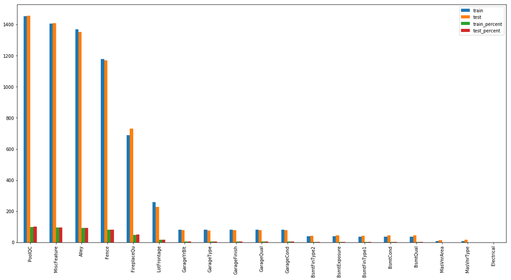

```python
null[null['train_percent'] != 0].plot(kind = 'bar', figsize = (20, 10))
plt.yticks(fontsize = 10);
plt.xticks(fontsize = 10);
```

```python
null[null.train_percent >= 50]

null[null.test_percent >= 50]
```

|  | train | test | train_percent | test_percent |
| --- | --- | --- | --- | --- |
| PoolQC | 1453 | 1456.0 | 99.52 | 99.79 |
| MiscFeature | 1406 | 1408.0 | 96.30 | 96.50 |
| Alley | 1369 | 1352.0 | 93.77 | 92.67 |
| Fence | 1179 | 1169.0 | 80.75 | 80.12 |
| FireplaceQu | 690 | 730.0 | 47.26 | 50.03 |

```python
train.describe()
```

|  | Id | MSSubClass | LotFrontage | LotArea | OverallQual | OverallCond | YearBuilt | YearRemodAdd | MasVnrArea | BsmtFinSF1 | ... | WoodDeckSF | OpenPorchSF | EnclosedPorch | 3SsnPorch | ScreenPorch | PoolArea | MiscVal | MoSold | YrSold | SalePrice |
| --- | --- | --- | --- | --- | --- | --- | --- | --- | --- | --- | --- | --- | --- | --- | --- | --- | --- | --- | --- | --- | --- |
| count | 1460.000000 | 1460.000000 | 1201.000000 | 1460.000000 | 1460.000000 | 1460.000000 | 1460.000000 | 1460.000000 | 1452.000000 | 1460.000000 | ... | 1460.000000 | 1460.000000 | 1460.000000 | 1460.000000 | 1460.000000 | 1460.000000 | 1460.000000 | 1460.000000 | 1460.000000 | 1460.000000 |
| mean | 730.500000 | 56.897260 | 70.049958 | 10516.828082 | 6.099315 | 5.575342 | 1971.267808 | 1984.865753 | 103.685262 | 443.639726 | ... | 94.244521 | 46.660274 | 21.954110 | 3.409589 | 15.060959 | 2.758904 | 43.489041 | 6.321918 | 2007.815753 | 180921.195890 |
| std | 421.610009 | 42.300571 | 24.284752 | 9981.264932 | 1.382997 | 1.112799 | 30.202904 | 20.645407 | 181.066207 | 456.098091 | ... | 125.338794 | 66.256028 | 61.119149 | 29.317331 | 55.757415 | 40.177307 | 496.123024 | 2.703626 | 1.328095 | 79442.502883 |
| min | 1.000000 | 20.000000 | 21.000000 | 1300.000000 | 1.000000 | 1.000000 | 1872.000000 | 1950.000000 | 0.000000 | 0.000000 | ... | 0.000000 | 0.000000 | 0.000000 | 0.000000 | 0.000000 | 0.000000 | 0.000000 | 1.000000 | 2006.000000 | 34900.000000 |
| 25% | 365.750000 | 20.000000 | 59.000000 | 7553.500000 | 5.000000 | 5.000000 | 1954.000000 | 1967.000000 | 0.000000 | 0.000000 | ... | 0.000000 | 0.000000 | 0.000000 | 0.000000 | 0.000000 | 0.000000 | 0.000000 | 5.000000 | 2007.000000 | 129975.000000 |
| 50% | 730.500000 | 50.000000 | 69.000000 | 9478.500000 | 6.000000 | 5.000000 | 1973.000000 | 1994.000000 | 0.000000 | 383.500000 | ... | 0.000000 | 25.000000 | 0.000000 | 0.000000 | 0.000000 | 0.000000 | 0.000000 | 6.000000 | 2008.000000 | 163000.000000 |
| 75% | 1095.250000 | 70.000000 | 80.000000 | 11601.500000 | 7.000000 | 6.000000 | 2000.000000 | 2004.000000 | 166.000000 | 712.250000 | ... | 168.000000 | 68.000000 | 0.000000 | 0.000000 | 0.000000 | 0.000000 | 0.000000 | 8.000000 | 2009.000000 | 214000.000000 |
| max | 1460.000000 | 190.000000 | 313.000000 | 215245.000000 | 10.000000 | 9.000000 | 2010.000000 | 2010.000000 | 1600.000000 | 5644.000000 | ... | 857.000000 | 547.000000 | 552.000000 | 508.000000 | 480.000000 | 738.000000 | 15500.000000 | 12.000000 | 2010.000000 | 755000.000000 |

8 rows × 38 columns

```python
train.describe(include = 'object')
```

|  | MSZoning | Street | Alley | LotShape | LandContour | Utilities | LotConfig | LandSlope | Neighborhood | Condition1 | ... | GarageType | GarageFinish | GarageQual | GarageCond | PavedDrive | PoolQC | Fence | MiscFeature | SaleType | SaleCondition |
| --- | --- | --- | --- | --- | --- | --- | --- | --- | --- | --- | --- | --- | --- | --- | --- | --- | --- | --- | --- | --- | --- |
| count | 1460 | 1460 | 91 | 1460 | 1460 | 1460 | 1460 | 1460 | 1460 | 1460 | ... | 1379 | 1379 | 1379 | 1379 | 1460 | 7 | 281 | 54 | 1460 | 1460 |
| unique | 5 | 2 | 2 | 4 | 4 | 2 | 5 | 3 | 25 | 9 | ... | 6 | 3 | 5 | 5 | 3 | 3 | 4 | 4 | 9 | 6 |
| top | RL | Pave | Grvl | Reg | Lvl | AllPub | Inside | Gtl | NAmes | Norm | ... | Attchd | Unf | TA | TA | Y | Gd | MnPrv | Shed | WD | Normal |
| freq | 1151 | 1454 | 50 | 925 | 1311 | 1459 | 1052 | 1382 | 225 | 1260 | ... | 870 | 605 | 1311 | 1326 | 1340 | 3 | 157 | 49 | 1267 | 1198 |

4 rows × 43 columns

```python
test.describe()
```

|  | Id | MSSubClass | LotFrontage | LotArea | OverallQual | OverallCond | YearBuilt | YearRemodAdd | MasVnrArea | BsmtFinSF1 | ... | GarageArea | WoodDeckSF | OpenPorchSF | EnclosedPorch | 3SsnPorch | ScreenPorch | PoolArea | MiscVal | MoSold | YrSold |
| --- | --- | --- | --- | --- | --- | --- | --- | --- | --- | --- | --- | --- | --- | --- | --- | --- | --- | --- | --- | --- | --- |
| count | 1459.000000 | 1459.000000 | 1232.000000 | 1459.000000 | 1459.000000 | 1459.000000 | 1459.000000 | 1459.000000 | 1444.000000 | 1458.000000 | ... | 1458.000000 | 1459.000000 | 1459.000000 | 1459.000000 | 1459.000000 | 1459.000000 | 1459.000000 | 1459.000000 | 1459.000000 | 1459.000000 |
| mean | 2190.000000 | 57.378341 | 68.580357 | 9819.161069 | 6.078821 | 5.553804 | 1971.357779 | 1983.662783 | 100.709141 | 439.203704 | ... | 472.768861 | 93.174777 | 48.313914 | 24.243317 | 1.794380 | 17.064428 | 1.744345 | 58.167923 | 6.104181 | 2007.769705 |
| std | 421.321334 | 42.746880 | 22.376841 | 4955.517327 | 1.436812 | 1.113740 | 30.390071 | 21.130467 | 177.625900 | 455.268042 | ... | 217.048611 | 127.744882 | 68.883364 | 67.227765 | 20.207842 | 56.609763 | 30.491646 | 630.806978 | 2.722432 | 1.301740 |
| min | 1461.000000 | 20.000000 | 21.000000 | 1470.000000 | 1.000000 | 1.000000 | 1879.000000 | 1950.000000 | 0.000000 | 0.000000 | ... | 0.000000 | 0.000000 | 0.000000 | 0.000000 | 0.000000 | 0.000000 | 0.000000 | 0.000000 | 1.000000 | 2006.000000 |
| 25% | 1825.500000 | 20.000000 | 58.000000 | 7391.000000 | 5.000000 | 5.000000 | 1953.000000 | 1963.000000 | 0.000000 | 0.000000 | ... | 318.000000 | 0.000000 | 0.000000 | 0.000000 | 0.000000 | 0.000000 | 0.000000 | 0.000000 | 4.000000 | 2007.000000 |
| 50% | 2190.000000 | 50.000000 | 67.000000 | 9399.000000 | 6.000000 | 5.000000 | 1973.000000 | 1992.000000 | 0.000000 | 350.500000 | ... | 480.000000 | 0.000000 | 28.000000 | 0.000000 | 0.000000 | 0.000000 | 0.000000 | 0.000000 | 6.000000 | 2008.000000 |
| 75% | 2554.500000 | 70.000000 | 80.000000 | 11517.500000 | 7.000000 | 6.000000 | 2001.000000 | 2004.000000 | 164.000000 | 753.500000 | ... | 576.000000 | 168.000000 | 72.000000 | 0.000000 | 0.000000 | 0.000000 | 0.000000 | 0.000000 | 8.000000 | 2009.000000 |
| max | 2919.000000 | 190.000000 | 200.000000 | 56600.000000 | 10.000000 | 9.000000 | 2010.000000 | 2010.000000 | 1290.000000 | 4010.000000 | ... | 1488.000000 | 1424.000000 | 742.000000 | 1012.000000 | 360.000000 | 576.000000 | 800.000000 | 17000.000000 | 12.000000 | 2010.000000 |

8 rows × 37 columns

```python
test.describe(include = 'object')
```

|  | MSZoning | Street | Alley | LotShape | LandContour | Utilities | LotConfig | LandSlope | Neighborhood | Condition1 | ... | GarageType | GarageFinish | GarageQual | GarageCond | PavedDrive | PoolQC | Fence | MiscFeature | SaleType | SaleCondition |
| --- | --- | --- | --- | --- | --- | --- | --- | --- | --- | --- | --- | --- | --- | --- | --- | --- | --- | --- | --- | --- | --- |
| count | 1455 | 1459 | 107 | 1459 | 1459 | 1457 | 1459 | 1459 | 1459 | 1459 | ... | 1383 | 1381 | 1381 | 1381 | 1459 | 3 | 290 | 51 | 1458 | 1459 |
| unique | 5 | 2 | 2 | 4 | 4 | 1 | 5 | 3 | 25 | 9 | ... | 6 | 3 | 4 | 5 | 3 | 2 | 4 | 3 | 9 | 6 |
| top | RL | Pave | Grvl | Reg | Lvl | AllPub | Inside | Gtl | NAmes | Norm | ... | Attchd | Unf | TA | TA | Y | Ex | MnPrv | Shed | WD | Normal |
| freq | 1114 | 1453 | 70 | 934 | 1311 | 1457 | 1081 | 1396 | 218 | 1251 | ... | 853 | 625 | 1293 | 1328 | 1301 | 2 | 172 | 46 | 1258 | 1204 |

4 rows × 43 columns

Observation: Missing data in the dataset

In datatype numerics (integers + float):

- Missing data only in 3 Coulmns
- Missing data < 20% in Column LotFrontage
- Missing data < 6% in Column GarangeYrBlt
- Missing data < 1% in Column MasVnrArea

Very less number of Columns with missing values.

Columns having datatype object have high percentage of missing values as compared to columns with datatype intergers and float.

Due to huge data gap, Alley, PoolQC, Fence and MiscFeature cloumns have been deleted from the dataset

## Exploratory Data Analysis:

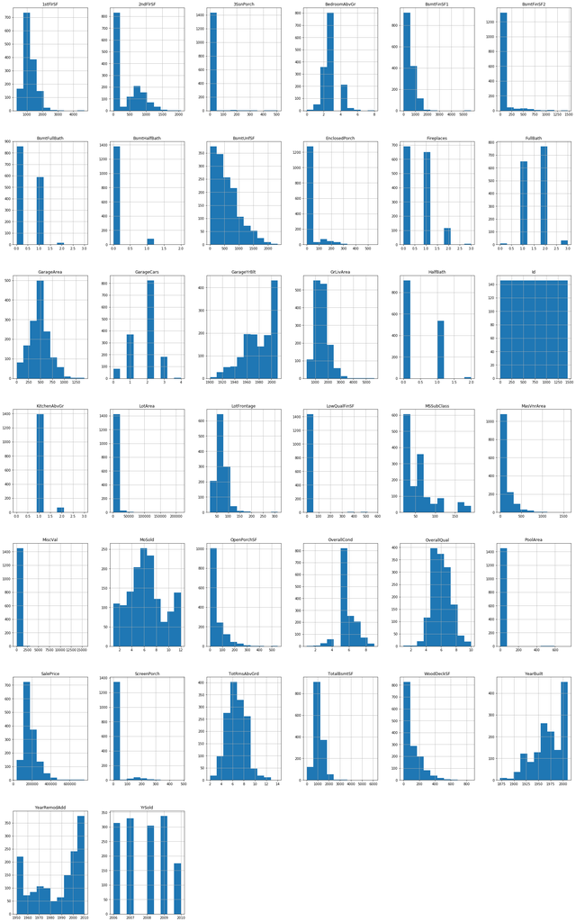

```python
# Creating Subplots for distribution for the data.

color = sns.color_palette()[0]

train.hist(figsize = (30, 50), color = color)
plt.yticks(fontsize = 8);
```

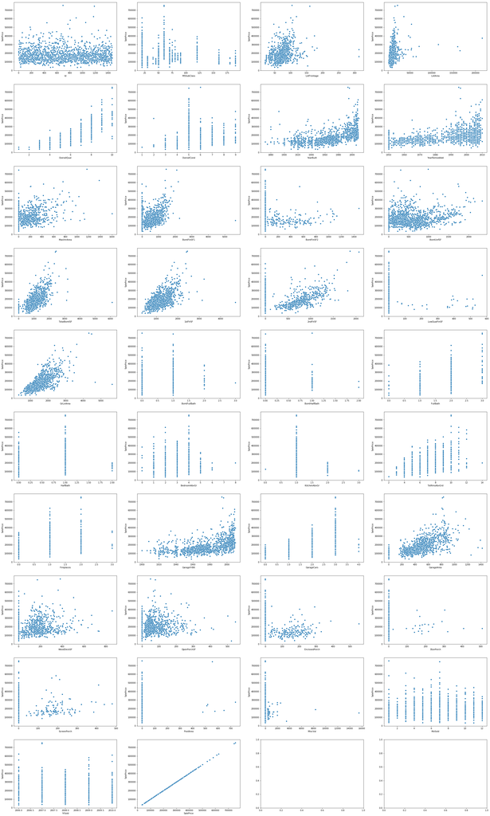

```python
# Creating Subplots using scatterplot for SalePrice v/s columns.

color = sns.color_palette()[0]

train_num = train.select_dtypes(include = ['int64','float64'])

fig, ax = plt.subplots(10, 4, figsize = (40, 70))

for i, ax in zip(train_num.columns, ax.flatten()):
    sns.scatterplot(x = i, y = 'SalePrice', data = train_num, ax = ax, color = color);
```

```python
n = train['Neighborhood'].value_counts()
d = train[train['Neighborhood'].isin(n.index[n > 20])]
```

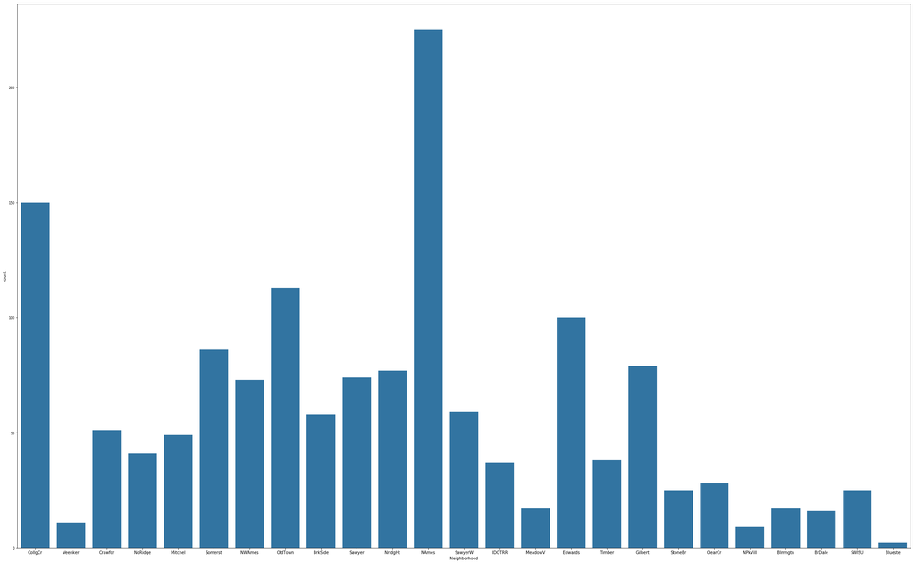

```python
color = sns.color_palette()[0]

plt.figure(figsize = (40,25))
sns.countplot(train['Neighborhood'], color = color)
plt.yticks(fontsize = 8);
```

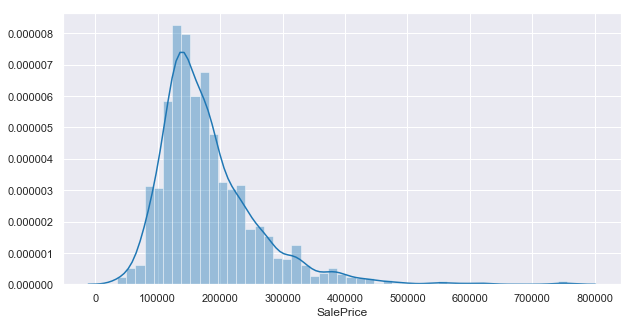

```python
color = sns.color_palette()[0]

plt.figure(figsize = (10, 5))
sns.set(font_scale = 1)
sns.distplot(train['SalePrice'], color = color);
```

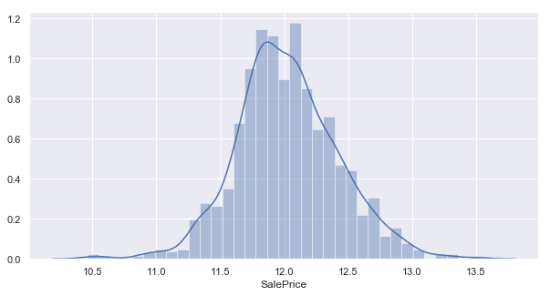

```python
color = sns.color_palette()[0]

plt.figure(figsize = (10, 5))
sns.set(font_scale = 1)
s = np.log1p(train['SalePrice'])
sns.distplot(s, color = color);
```

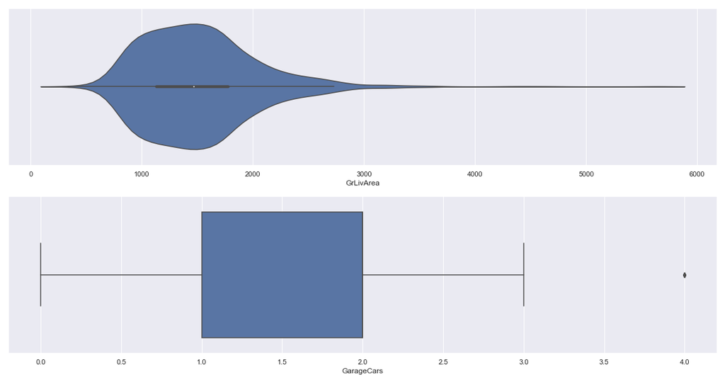

```python
color = sns.color_palette()[0]

plt.figure(figsize = (20,10))
sns.set(font_scale = 1)

plt.subplot(2,1,1)
sns.violinplot(train['GrLivArea'], color = color)

plt.subplot(2,1,2)
sns.boxplot(train['GarageCars'], color = color);
```

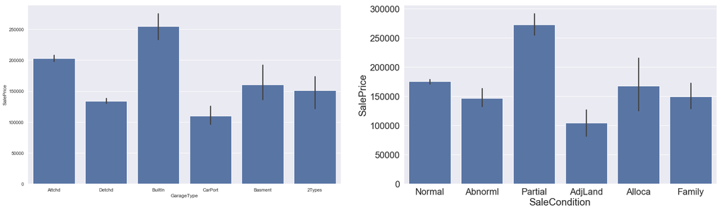

```python
color = sns.color_palette()[0]

plt.figure(figsize = (30,8))
plt.subplot(1,2,1)
sns.set(font_scale = 2)
sns.barplot(train['GarageType'], train['SalePrice'], color = color)

plt.subplot(1,2,2)
sns.set(font_scale = 2)
sns.barplot(train['SaleCondition'], train['SalePrice'], color = color);
```

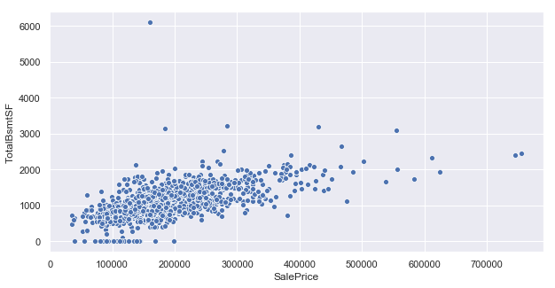

```python
color = sns.color_palette()[0]

plt.figure(figsize = (10, 5))
sns.set(font_scale = 1)
sns.scatterplot(train['SalePrice'], train['TotalBsmtSF'], color = color);
```

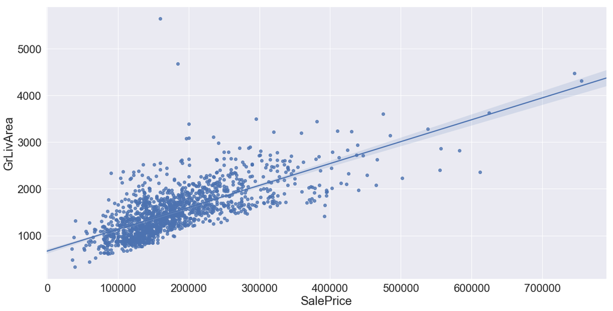

```python
color = sns.color_palette()[0]

plt.figure(figsize = (20,10))
sns.set(font_scale = 2)
sns.regplot(train['SalePrice'], train['GrLivArea'], color = color);
```

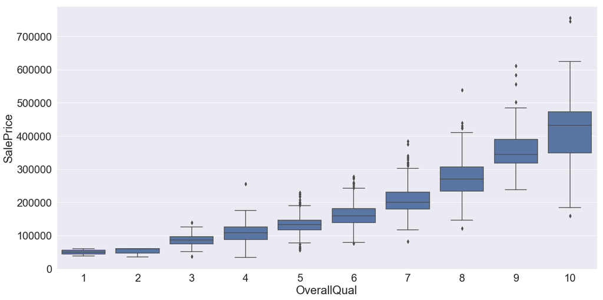

```python
color = sns.color_palette()[0]

plt.figure(figsize = (20,10))
sns.set(font_scale = 2)
sns.boxplot(y = train['SalePrice'], x = train['OverallQual'], color = color);
```

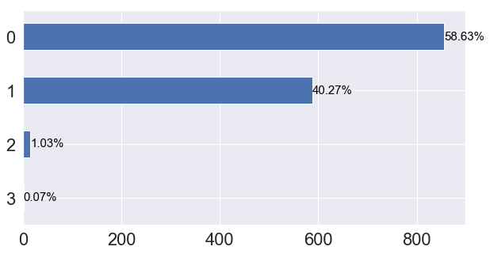

```python
color = sns.color_palette()[0]

plt.figure(figsize = (10,5))

ax = train['BsmtFullBath'].value_counts().sort_values().plot(kind = "barh", color = color)

total = []
for ele in ax.patches:
    total.append(ele.get_width())

sums = sum(total)

for ele in ax.patches:
     ax.text(ele.get_width()+.3, ele.get_y()+.20, str(round((ele.get_width()/sums)*100, 2))+'%', fontsize = 15, color = 'black')
```

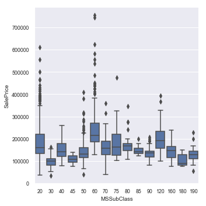

```python
color = sns.color_palette()[0]

plt.figure(figsize = (20,40))
sns.set(font_scale = 0.8)

sns.catplot(x = "MSSubClass", y = "SalePrice", data = train, kind = "box", color = color);
```

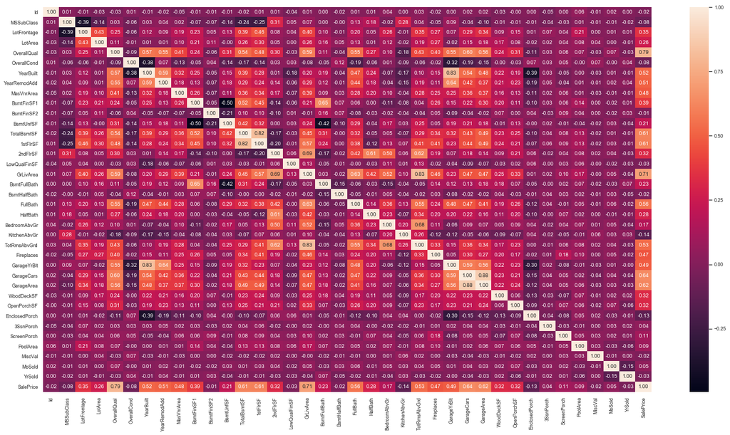

```python
plt.figure(figsize = (25,13))

sns.heatmap(train.corr(), annot = True, fmt = '.2f');
```

```python
#correlation matrix:

col = train.corr()[train.corr()['SalePrice'] > 0.1]['SalePrice'].sort_values().index
col
```

```
Index(['ScreenPorch', 'BedroomAbvGr', 'BsmtUnfSF', 'BsmtFullBath', 'LotArea',
       'HalfBath', 'OpenPorchSF', '2ndFlrSF', 'WoodDeckSF', 'LotFrontage',
       'BsmtFinSF1', 'Fireplaces', 'MasVnrArea', 'GarageYrBlt', 'YearRemodAdd',
       'YearBuilt', 'TotRmsAbvGrd', 'FullBath', '1stFlrSF', 'TotalBsmtSF',
       'GarageArea', 'GarageCars', 'GrLivArea', 'OverallQual', 'SalePrice'],
      dtype='object')
```

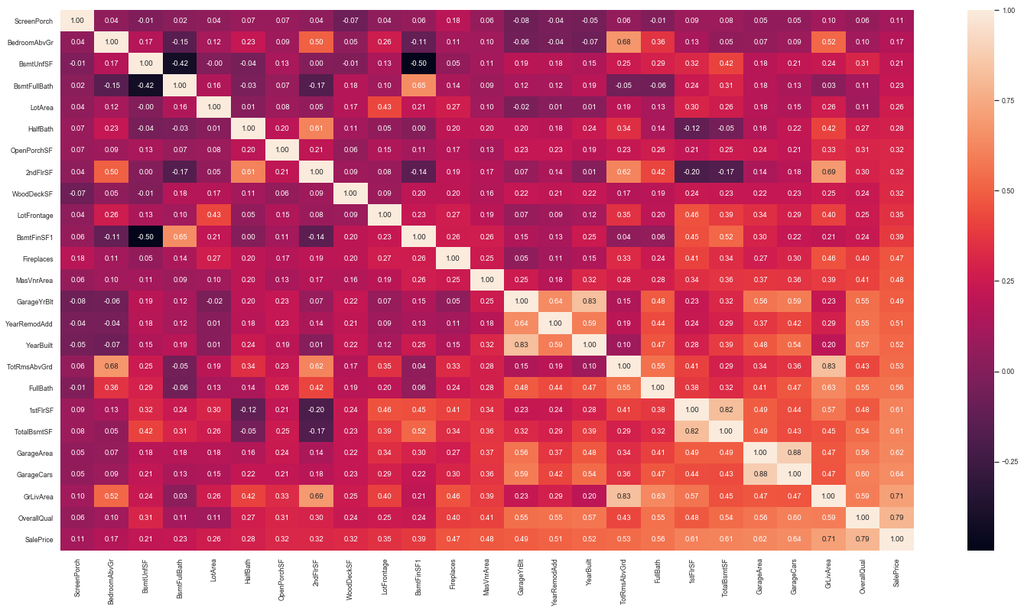

```python
# Heatmap with annotation of correlation values:

plt.figure(figsize = (25,13))

df = train[['ScreenPorch', 'BedroomAbvGr', 'BsmtUnfSF', 'BsmtFullBath', 'LotArea',
       'HalfBath', 'OpenPorchSF', '2ndFlrSF', 'WoodDeckSF', 'LotFrontage',
       'BsmtFinSF1', 'Fireplaces', 'MasVnrArea', 'GarageYrBlt', 'YearRemodAdd',
       'YearBuilt', 'TotRmsAbvGrd', 'FullBath', '1stFlrSF', 'TotalBsmtSF',
       'GarageArea', 'GarageCars', 'GrLivArea', 'OverallQual', 'SalePrice']]

sns.heatmap(df.corr(), annot = True, fmt = '.2f');
```

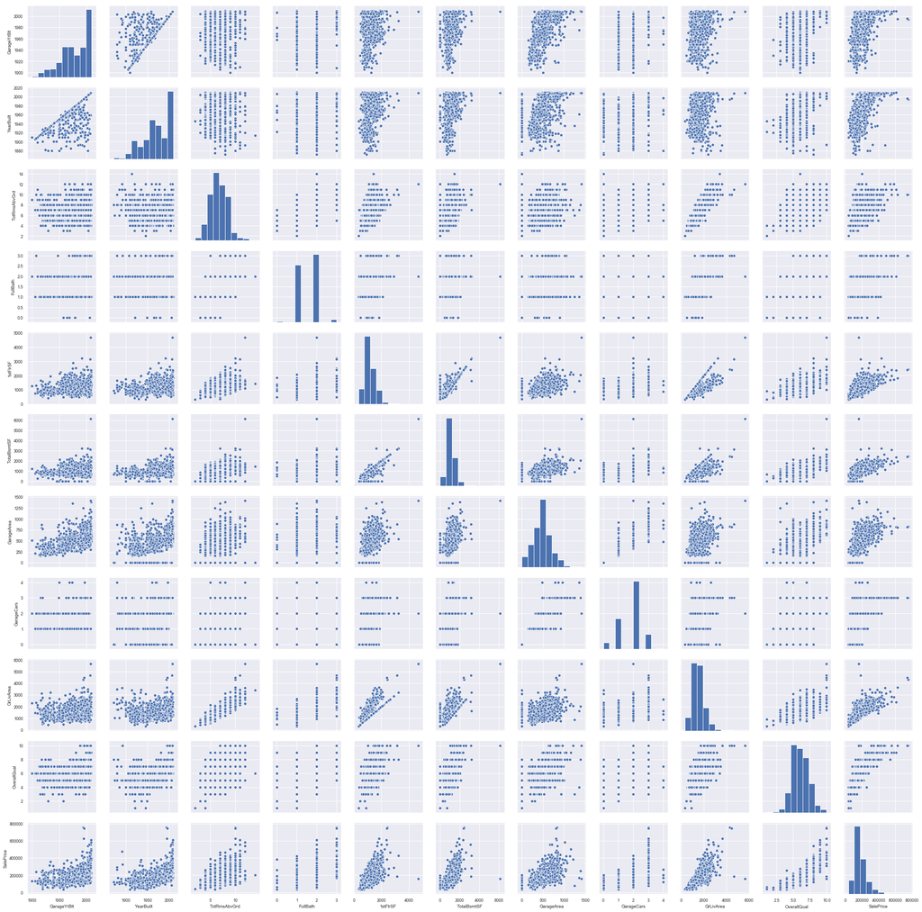

```python
d = train[['GarageYrBlt', 'YearBuilt', 'TotRmsAbvGrd', 'FullBath', '1stFlrSF', 'TotalBsmtSF',
       'GarageArea', 'GarageCars', 'GrLivArea', 'OverallQual', 'SalePrice']]

sns.pairplot(d);
```

We also can detect that some quantitative fetures are actually categorical, like 'MoSold' or 'OverallQual'.

## Data pre processing:

```python
train.dropna(subset = ['SalePrice'], axis = 0, inplace = True)
```

```python
train.drop(['PoolQC', 'MiscFeature', 'Fence', 'Alley', 'FireplaceQu'], axis = 1, inplace = True)
test.drop(['PoolQC', 'MiscFeature', 'Fence', 'Alley', 'FireplaceQu'], axis = 1, inplace = True)
```

```python
train.drop(['Id', 'Utilities'], axis = 1, inplace = True)
test.drop(['Id', 'Utilities'], axis = 1, inplace = True)
```

```python
train.drop(['GarageCars', 'TotRmsAbvGrd', 'GarageYrBlt'], axis = 1, inplace = True)
test.drop(['GarageCars', 'TotRmsAbvGrd', 'GarageYrBlt'], axis = 1, inplace = True)
```

```python
train['Electrical'] = train['Electrical'].astype('object')
test['Electrical'] = test['Electrical'].astype('object')
```

```python
t = test['BsmtFinSF1']+test['BsmtFinSF2']+test['BsmtUnfSF']
t = t.to_list()
total = test['TotalBsmtSF'].to_list()

d = pd.DataFrame()
d['t'] = t
d['total'] = total

d.head()
```

|  | t | total |
| --- | --- | --- |
| 0 | 882.0 | 882.0 |
| 1 | 1329.0 | 1329.0 |
| 2 | 928.0 | 928.0 |
| 3 | 926.0 | 926.0 |
| 4 | 1280.0 | 1280.0 |

```python
train_OverAllSF = train['TotalBsmtSF'] + train['1stFlrSF'] + train['2ndFlrSF']
train['OverAllSF'] = train_OverAllSF
test['OverAllSF'] = train_OverAllSF


test_OverAllSF = test['TotalBsmtSF'] + test['1stFlrSF'] + test['2ndFlrSF']
test['OverAllSF'] = test_OverAllSF
test['OverAllSF'] = test_OverAllSF
```

```python
train_HouseAge = train['YrSold'] - train['YearBuilt']
test_HouseAge = test['YrSold'] - test['YearBuilt']


train['HouseAge'] = train_HouseAge
test['HouseAge'] = test_HouseAge
```

```python
train.drop(['BsmtFinSF1', 'BsmtFinSF2', 'BsmtUnfSF', 'YrSold', 'YearBuilt', '1stFlrSF', '2ndFlrSF'], axis = 1, inplace = True)
test.drop(['BsmtFinSF1', 'BsmtFinSF2', 'BsmtUnfSF', 'YrSold', 'YearBuilt', '1stFlrSF', '2ndFlrSF'], axis = 1, inplace = True)
```

As we found before, many columns has NaN values, but if we explore our data more, we understand that in some features NaN values meen lack of some characteristic. For instance, no pool, no garage, etc. That's why we can fill gaps by zero or None in these columns.

```python
train_cat = [ele for ele in train.columns if train[ele].dtype == 'object']
train_num = [ele for ele in train.columns if train[ele].dtype in ['float', 'int']]

test_cat = [ele for ele in test.columns if test[ele].dtype == 'object']
test_num = [ele for ele in test.columns if test[ele].dtype in ['float', 'int']]
```

```python
for ele in train_cat:
    train[ele] = train[ele].fillna('Unknown')

for ele in test_cat:
    test[ele] = test[ele].fillna('Unknown')
```

```python
for ele in train_num:
    train[ele] = train[ele].fillna(0)


for ele in test_num:
    test[ele] = test[ele].fillna(0)
```

```python
train.shape
```

```
(1460, 66)
```

```python
test.shape
```

```
(1459, 65)
```

## Stats model:

```python
reg = smf.ols('SalePrice ~ ScreenPorch + BedroomAbvGr + BsmtFullBath + LotArea + WoodDeckSF + Fireplaces + MasVnrArea + YearRemodAdd + TotalBsmtSF + GarageArea + GrLivArea + OverallQual', data = train).fit()
print(reg.summary())

table = sm.stats.anova_lm(reg)
table

p = table["PR(>F)"][0]

coeff, p = None, round(p, 3)

conclusion = "Correlated" if p < 0.05 else "Non-Correlated"

print("Anova F-test: the variables are", conclusion, "(p-value: "+str(p)+")")
```

```
                            OLS Regression Results
==============================================================================
Dep. Variable:              SalePrice   R-squared:                       0.791
Model:                            OLS   Adj. R-squared:                  0.790
Method:                 Least Squares   F-statistic:                     457.3
Date:                Sun, 04 Dec 2022   Prob (F-statistic):               0.00
Time:                        16:12:06   Log-Likelihood:                -17400.
No. Observations:                1460   AIC:                         3.483e+04
Df Residuals:                    1447   BIC:                         3.489e+04
Df Model:                          12
Covariance Type:            nonrobust
================================================================================
                   coef    std err          t      P>|t|      [0.025      0.975]
--------------------------------------------------------------------------------
Intercept    -9.243e+05   1.11e+05     -8.328      0.000   -1.14e+06   -7.07e+05
ScreenPorch     49.7632     17.584      2.830      0.005      15.269      84.257
BedroomAbvGr -4580.2945   1491.396     -3.071      0.002   -7505.825   -1654.764
BsmtFullBath  1.105e+04   2001.460      5.520      0.000    7122.839     1.5e+04
LotArea          0.4793      0.104      4.607      0.000       0.275       0.683
WoodDeckSF      32.6195      8.181      3.987      0.000      16.572      48.667
Fireplaces    6367.2158   1787.757      3.562      0.000    2860.343    9874.088
MasVnrArea      36.4114      6.034      6.034      0.000      24.575      48.248
YearRemodAdd   435.7771     57.179      7.621      0.000     323.615     547.939
TotalBsmtSF     18.1440      2.892      6.274      0.000      12.471      23.817
GarageArea      42.2764      5.803      7.285      0.000      30.893      53.660
GrLivArea       45.5435      3.095     14.714      0.000      39.472      51.615
OverallQual   2.032e+04   1118.342     18.169      0.000    1.81e+04    2.25e+04
==============================================================================
Omnibus:                      643.562   Durbin-Watson:                   1.966
Prob(Omnibus):                  0.000   Jarque-Bera (JB):           103408.982
Skew:                          -0.955   Prob(JB):                         0.00
Kurtosis:                      44.185   Cond. No.                     1.70e+06
==============================================================================

Warnings:
[1] Standard Errors assume that the covariance matrix of the errors is correctly specified.
[2] The condition number is large, 1.7e+06. This might indicate that there are
strong multicollinearity or other numerical problems.
Anova F-test: the variables are Correlated (p-value: 0.0)
```

```python
df_train = train.copy()
df_test = test.copy()
```

## Data Labelling:

Next we should convert all categorical features to numerical.

```python
for ele in train_cat:
    l = LabelEncoder()
    df_train[ele] = l.fit_transform(df_train[ele].astype(str))


for ele in test_cat:
    l = LabelEncoder()
    df_test[ele] = l.fit_transform(df_test[ele].astype(str))
```

## Data Standardizing:

```python
s = StandardScaler()

for col in train_num:
    df_train[col] = s.fit_transform(df_train[col].values.reshape(-1, 1))

for col in test_num:
    df_test[col] = s.fit_transform(df_test[col].values.reshape(-1, 1))
```

## Dummy variables:

```python
data_train = pd.get_dummies(df_train, columns = train_cat, drop_first = True)
data_test = pd.get_dummies(df_test, columns = test_cat, drop_first = True)
```

```python
data_train.drop(train_num, axis = 1, inplace = True)
data_test.drop(test_num, axis = 1, inplace = True)
```

```python
df_train = pd.concat([df_train, data_train], axis = 1)
df_test = pd.concat([df_test, data_test], axis = 1)
```

```python
df_train.shape
```

```
(1460, 272)
```

```python
df_test.shape
```

```
(1459, 261)
```

```python
remCols = list(set(df_train.columns) - set(df_test.columns))
for col in remCols:
    if(col != 'SalePrice'):
        df_test[col] = 0
set(df_train.columns) - set(df_test.columns)
```

```
{'SalePrice'}
```

```python
d = ['Functional_7', 'KitchenQual_4', 'MSZoning_5', 'SaleType_9']
df_test.drop(d, inplace = True, axis = 1)
```

```python
df_train.shape
```

```
(1460, 272)
```

```python
df_test.shape
```

```
(1459, 271)
```

## Modeling:

Split scaled Train dataset into:

80% training set.

20% validation set.

```python
# Split data:

y = df_train['SalePrice']
X = df_train.drop('SalePrice', axis = 1)
```

```python
# Create training and testing sets:

X_train, X_test, y_train, y_test = train_test_split(X, y, test_size = 0.2, random_state = 42)
```

```python
print(X_train.shape)
print(X_test.shape)

print(y_train.shape)
print(y_test.shape)
```

```
(1168, 271)
(292, 271)
(1168,)
(292,)
```

```python
print(X_train.shape[1], "features:", X_train.columns.to_list())
```

```
271 features: ['MSSubClass', 'MSZoning', 'LotFrontage', 'LotArea', 'Street', 'LotShape', 'LandContour', 'LotConfig', 'LandSlope', 'Neighborhood', 'Condition1', 'Condition2', 'BldgType', 'HouseStyle', 'OverallQual', 'OverallCond', 'YearRemodAdd', 'RoofStyle', 'RoofMatl', 'Exterior1st', 'Exterior2nd',…
```

```
                      imp
var
OverAllSF        0.424878
OverallQual      0.314244
HouseAge         0.034295
GrLivArea        0.023802
BsmtQual         0.022151
YearRemodAdd     0.018443
GarageFinish     0.016780
LotArea          0.016595
GarageArea       0.011492
PoolArea         0.010862
TotalBsmtSF      0.010576
Neighborhood     0.008678
Fireplaces       0.008338
OverallCond      0.006609
BsmtFullBath     0.006373
KitchenQual      0.005582
Neighborhood_7   0.005127
KitchenAbvGr     0.004609
GarageType       0.003820
OpenPorchSF      0.003273
CentralAir       0.002954
Neighborhood_6   0.002765
ScreenPorch      0.002535
LotFrontage      0.002169
FullBath         0.002134
KitchenQual_2    0.002115
BsmtExposure_1   0.001888
BsmtFinType1_2   0.001753
SaleType_6       0.001607
BsmtFinType1     0.001589
MasVnrArea       0.001384
Neighborhood_22  0.001333
Neighborhood_15  0.001218
BsmtExposure     0.001192
Exterior1st_3    0.001169
LotShape         0.001097
LotConfig_1      0.001013
SaleCondition    0.001006
LandContour      0.000993
HalfBath         0.000839
```

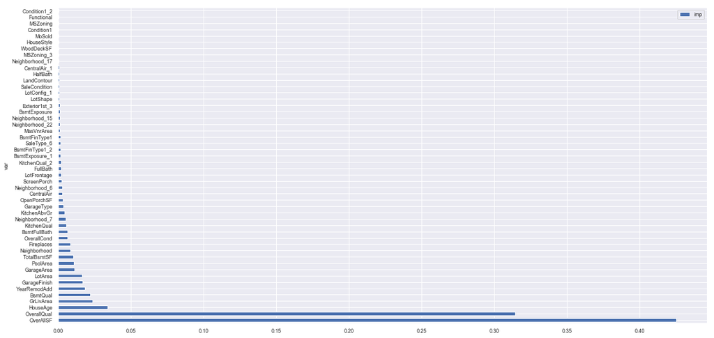

```python
# Top columns for prediction:

feature_names = X_train.columns

model = GradientBoostingRegressor()
model.fit(X_train, y_train)

importances = model.feature_importances_

d = pd.DataFrame({"imp": importances, "var": feature_names}).sort_values("imp", ascending = False)
d = d.set_index("var")

col = d[["imp"]].sort_values(by = "imp", ascending = False)[:40]
print(col)

d[["imp"]].sort_values(by = "imp", ascending = False)[:50].plot(kind = "barh", figsize = (20, 10));
```

```python
print(X_train.shape)
print(X_test.shape)

print(y_train.shape)
print(y_test.shape)
```

```
(1168, 271)
(292, 271)
(1168,)
(292,)
```

```python
# function for checking accuracy:

def predict_score(model, X_train, y_train, X_test, y_test):

    results = {}

    # Fit the model to the training data:
    model.fit(X_train, y_train)

    # predict on the testing data:
    pred = model.predict(X_test)

    results['r2_score'] = r2_score(y_test, pred)
    results['mean_squared_error'] = mean_squared_error(pred, y_test)
    results['mean_absolute_error'] = mean_absolute_error(y_test, pred)

    return results
```

```python
# Initialize the models

rfr = RandomForestRegressor(n_estimators = 200, random_state = 42)
gbr = GradientBoostingRegressor()
dtr = DecisionTreeRegressor()
ada = AdaBoostRegressor()
```

```python
# Collect results on the models:

results = {}

for model in [rfr, gbr, dtr, ada]:
    model_name = model.__class__.__name__
    results[model_name] = {}
    results[model_name] = predict_score(model, X_train, y_train, X_test, y_test)


results
```

```
{'RandomForestRegressor': {'r2_score': 0.8724676518372181,
  'mean_squared_error': 0.15510504262811295,
  'mean_absolute_error': 0.2272398167780897},
 'GradientBoostingRegressor': {'r2_score': 0.8991409349192647,
  'mean_squared_error': 0.12266495374813784,
  'mean_absolute_error': 0.2087182905936062},
 'DecisionTreeRegressor': {'r2_score': 0.7614617200207129,
  'mean_squared_error': 0.29011063167596735,
  'mean_absolute_error': 0.335835479154346},
 'AdaBoostRegressor': {'r2_score': 0.8549792187951287,
  'mean_squared_error': 0.17637450242846003,
  'mean_absolute_error': 0.29997079212270306}}
```

```python
# Display results:

for ele in results.items():
    print(ele[0])
    display(pd.DataFrame(ele[1], index = range(1)))
```

```
RandomForestRegressor
```

|  | r2_score | mean_squared_error | mean_absolute_error |
| --- | --- | --- | --- |
| 0 | 0.872468 | 0.155105 | 0.22724 |

```
GradientBoostingRegressor
```

|  | r2_score | mean_squared_error | mean_absolute_error |
| --- | --- | --- | --- |
| 0 | 0.899141 | 0.122665 | 0.208718 |

```
DecisionTreeRegressor
```

|  | r2_score | mean_squared_error | mean_absolute_error |
| --- | --- | --- | --- |
| 0 | 0.761462 | 0.290111 | 0.335835 |

```
AdaBoostRegressor
```

|  | r2_score | mean_squared_error | mean_absolute_error |
| --- | --- | --- | --- |
| 0 | 0.854979 | 0.176375 | 0.299971 |

## Model Refinement / Hyperparameter Tuning:

We will fine tune our model using grid search technique. Where we will need to tell which hyper parameters we want to experiment and what values to try out, and grid search technique will evaluate all the possible combination of hyper parameters values, using cross validation.

```python
gbr = GradientBoostingRegressor()

gbr.fit(X_train, y_train)


n_estimators = [100, 200, 300]
max_features = [25, 45, 50]
max_depth = [15, 13, 18]
max_leaf_nodes = [8, 10, 13]


param_grid = { 'n_estimators': n_estimators,
                'max_features': max_features,
                'max_depth': max_depth,
                'max_leaf_nodes': max_leaf_nodes }

search = GridSearchCV(estimator = gbr, param_grid = param_grid, cv = 5, n_jobs = -1)
search.fit(X_train, y_train)

y_pred = search.predict(X_test)
print(r2_score(y_test, y_pred))

search.best_params_
```

```
0.8966102126058952
```

```
{'max_depth': 18, 'max_features': 50, 'max_leaf_nodes': 8, 'n_estimators': 300}
```

```python
ytest = s.inverse_transform(y_test)
ypred = s.inverse_transform(y_pred)
```

```python
df = pd.DataFrame({'Actual': ytest, 'Predicted': ypred})
df['residual'] = df['Actual'] - df['Predicted']
df.head(5)
```

|  | Actual | Predicted | residual |
| --- | --- | --- | --- |
| 0 | 26.290692 | 22.634358 | 3.656333 |
| 1 | 91.604558 | 106.408857 | -14.804299 |
| 2 | 11.159327 | 6.999375 | 4.159951 |
| 3 | 28.014518 | 23.917785 | 4.096733 |
| 4 | 87.965369 | 99.932161 | -11.966792 |

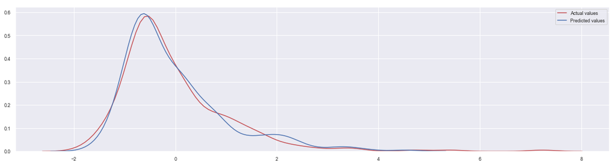

```python
# plot for actual and predicted values:

plt.figure(figsize = [20,5])

ax1 = sns.kdeplot(data = y_test, color = "r", label = 'Actual values')
ax2 = sns.kdeplot(data = y_pred, color = "b", label = 'Predicted values')
plt.legend();
```

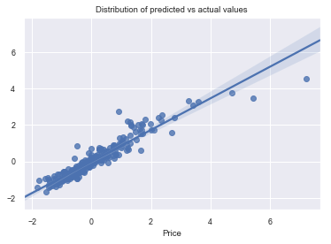

```python
sns.regplot(x = y_test, y = y_pred)
plt.title('Distribution of predicted vs actual values')
plt.xlabel('Price');
```

## Model Testing:

```python
test_price = search.predict(df_test)
```

```python
test_price = s.inverse_transform(test_price.reshape(-1,1)).reshape(-1)
```

```python
test = pd.read_csv("test_data.csv", sep = ',')
d = pd.DataFrame(test_price, columns = ['SalePrice'])
d.index = test['Id']
d.head()
```

| Id | SalePrice |
| --- | --- |
| 1461 | 14.629651 |
| 1462 | 15.963956 |
| 1463 | 38.161432 |
| 1464 | 36.589995 |
| 1465 | 33.843382 |

## Conclusion:

We have started the problem by exploring the data and then cleaning and after the preprocessing, we have ended with the model building step.

After going through a bunch of processes, we have successfully built and evaluated different types of regression models in python also, choosing the best model for our given dataset.

But, this won’t stop here. Each and every model we built have their own statistical and mathematical concepts. The reason why we have chosen these these models is because of its popularity.

There are also many other different linear regression models like the Poisson regression model, Boosted decision tree model, Decision tree model, and so on.

This model can also be used to predict the house prices in any geographic location by fine tuning the features and parameters.

#### Improvement:

I think I got good results for the prediction model.

I completely understood the data provided by Kaggle.

I believe that the idea of improving the data collection or fixing issues related with the missing data or NaNs would be really helpful.

In my opinion, I think that we can get great insights from this data set and great prediction models might be also built to solve problems statements associated with this data set.

#### Reflection:

I thoroughly enjoyed working on this project which allowed me to polish my skills in Data Preprocessing and Modeling.

The most difficult part in my opinion was understanding the dataset.

The Preprocessing step was the longest and most challenging part to complete.

The Dataset itself is inspiring.

## GitHub:

https://github.com/shriyutha/House-Price-Prediction-.git